# Project-Write-Up

Student Performance Analysis

```python
import matplotlib.pyplot as plt
import numpy as np
import pandas as pd
import seaborn as sns
from sklearn import linear_model, model_selection, metrics
from sklearn.tree import DecisionTreeClassifier, DecisionTreeRegressor, plot_tree
from sklearn.ensemble import RandomForestClassifier, RandomForestRegressor
from sklearn.preprocessing import LabelEncoder
from sklearn.model_selection import train_test_split
from sklearn.metrics import accuracy_score, confusion_matrix, classification_report, mean_squared_error, r2_score

df = pd.read_csv(r"\Users\giann\OneDrive\Documents\student\student-mat.csv", sep=";", quotechar='"')
df.columns = df.columns.str.strip()

print(df.describe())
mean_value = df['G3'].mean()
median_value = df['G3'].median()
std_dev = df['G3'].std()
```

```
              age        Medu        Fedu  traveltime   studytime    failures  \
count  395.000000  395.000000  395.000000  395.000000  395.000000  395.000000
mean    16.696203    2.749367    2.521519    1.448101    2.035443    0.334177
std      1.276043    1.094735    1.088201    0.697505    0.839240    0.743651
min     15.000000    0.000000    0.000000    1.000000    1.000000    0.000000
25%     16.000000    2.000000    2.000000    1.000000    1.000000    0.000000
50%     17.000000    3.000000    2.000000    1.000000    2.000000    0.000000
75%     18.000000    4.000000    3.000000    2.000000    2.000000    0.000000
max     22.000000    4.000000    4.000000    4.000000    4.000000    3.000000

           famrel    freetime       goout        Dalc        Walc      health  \
count  395.000000  395.000000  395.000000  395.000000  395.000000  395.000000
mean     3.944304    3.235443    3.108861    1.481013    2.291139    3.554430
std      0.896659    0.998862    1.113278    0.890741    1.287897    1.390303
min      1.000000    1.000000    1.000000    1.000000    1.000000    1.000000
25%      4.000000    3.000000    2.000000    1.000000    1.000000    3.000000
50%      4.000000    3.000000    3.000000    1.000000    2.000000    4.000000
75%      5.000000    4.000000    4.000000    2.000000    3.000000    5.000000
max      5.000000    5.000000    5.000000    5.000000    5.000000    5.000000

         absences          G1          G2          G3
count  395.000000  395.000000  395.000000  395.000000
mean     5.708861   10.908861   10.713924   10.415190
std      8.003096    3.319195    3.761505    4.581443
min      0.000000    3.000000    0.000000    0.000000
25%      0.000000    8.000000    9.000000    8.000000
50%      4.000000   11.000000   11.000000   11.000000
75%      8.000000   13.000000   13.000000   14.000000
max     75.000000   19.000000   19.000000   20.000000
```

https://archive.ics.uci.edu/dataset/320/student+performance

Description: The dataset focuses on the information of students from two Portuguese schools and their academic performances. There are 33 variables including sex, age, activities, study time, absences, and details about the students. The mean for G3 (final grades) is 10.42, the std is 4.58, the min is 0, and the max is 20. We decided to modify the data by removing white spaces, semicolons, and quotations.

Our questions are: Do students at certain schools receive better grades? and Do students who study less fail more classes?

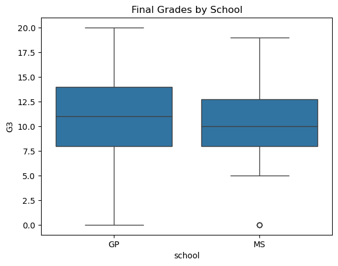

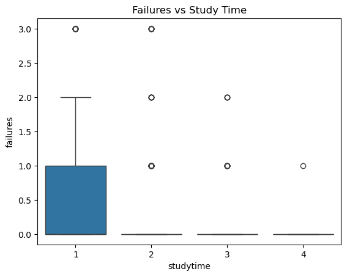

```python
#Do students at certain schools receive better grades?
sns.boxplot(data=df, x="school", y="G3")
plt.title("Final Grades by School")
plt.show()
#The boxplot shows that on average Gabriel Pereira seems to have a sligher higher final grades than Mousinho da Silveira, but GP's range of final grades is larger as well.

#Do students who study less fail more classes?
sns.boxplot(data=df, x="studytime", y="failures")
plt.title("Failures vs Study Time")
plt.show()
#Students who study more are less likely to fail, students who spend 2 or more hours studying tend to have less failures than those who spend only one hour. Those who study for one hour show the more variability and highest failure count.
```

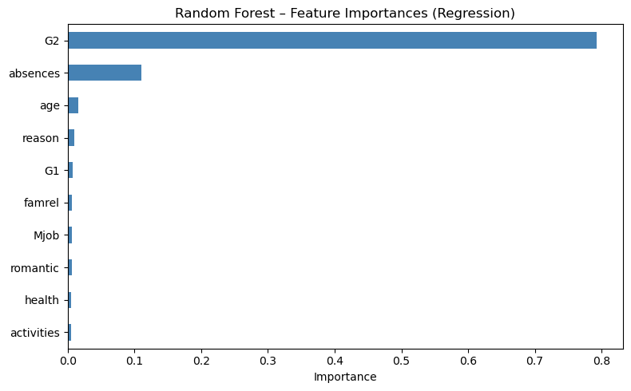

```
RMSE: 1.867281920908543
R2: 0.8299569015097052
```

```python
#Machine Learning
#Quantitative - using the variables to predict the student's final grades

le = LabelEncoder()
df_enc = df.copy()
for col in df.select_dtypes(include='object').columns:
    df_enc[col] = le.fit_transform(df_enc[col])

X = df_enc.drop(columns=['G3'])
y = df_enc['G3']
X_train, X_test, y_train, y_test = train_test_split(X, y, test_size=0.2, random_state=42)

model = RandomForestRegressor(n_estimators=100, random_state=42)
model.fit(X_train, y_train)
y_pred = model.predict(X_test)

feat_imp = pd.Series(model.feature_importances_, index=X.columns).sort_values(ascending=True).tail(10)
plt.figure(figsize=(8, 5))
feat_imp.plot(kind='barh', color='steelblue')
plt.title('Random Forest – Feature Importances (Regression)')
plt.xlabel('Importance')
plt.tight_layout()
plt.show()

print("RMSE:", np.sqrt(mean_squared_error(y_test, y_pred)))
print("R2:", r2_score(y_test, y_pred))
```

Independent variables: All columns except G3 Dependent variable: G3 - the student's final grade RMSE = 1.867 R^2 = 0.83

The model explains 83% of the variance in final grades and on average, the predictions are off by less than 2 points. The model does not seem to be overfitting or underfitting. The results are good and we would recommend the model for prediction.

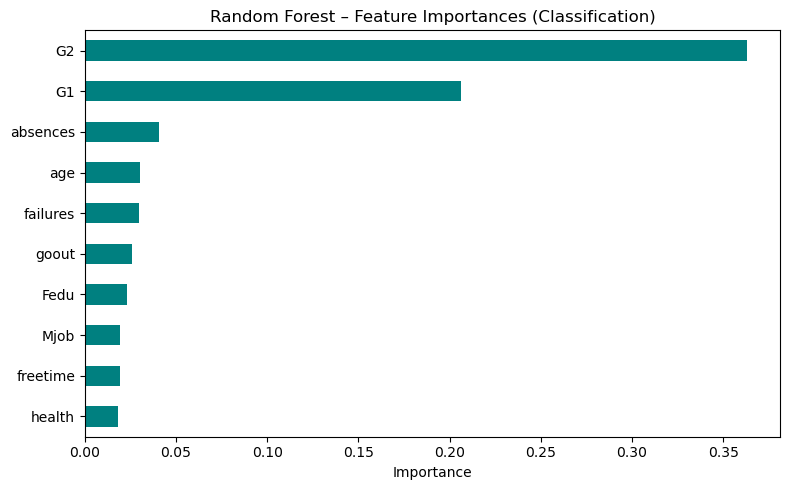

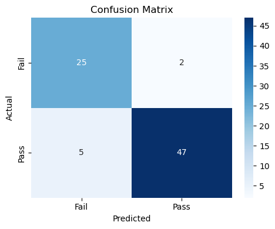

```
Accuracy: 0.9113924050632911
Confusion Matrix:
 [[25  2]
 [ 5 47]]
              precision    recall  f1-score   support

        Fail       0.83      0.93      0.88        27
        Pass       0.96      0.90      0.93        52

    accuracy                           0.91        79
   macro avg       0.90      0.91      0.90        79
weighted avg       0.92      0.91      0.91        79
```

```python
#Categorical
df_enc['pass'] = (df_enc['G3'] >= 10).astype(int)
X2 = df_enc.drop(columns=['G3', 'pass'])
y2 = df_enc['pass']
X_train2, X_test2, y_train2, y_test2 = train_test_split(X2, y2, test_size=0.2, random_state=42)

clf = RandomForestClassifier(n_estimators=100, random_state=42)
clf.fit(X_train2, y_train2)
y_pred2 = clf.predict(X_test2)

feat_imp2 = pd.Series(clf.feature_importances_, index=X2.columns).sort_values(ascending=True).tail(10)
plt.figure(figsize=(8, 5))
feat_imp2.plot(kind='barh', color='teal')
plt.title('Random Forest – Feature Importances (Classification)')
plt.xlabel('Importance')
plt.tight_layout()
plt.show()

cm = confusion_matrix(y_test2, y_pred2)
plt.figure(figsize=(5, 4))
sns.heatmap(cm, annot=True, fmt='d', cmap='Blues',
            xticklabels=['Fail', 'Pass'],
            yticklabels=['Fail', 'Pass'])
plt.title('Confusion Matrix')
plt.xlabel('Predicted')
plt.ylabel('Actual')
plt.tight_layout()
plt.show()

print("Accuracy:", accuracy_score(y_test2, y_pred2))
print("Confusion Matrix:\n", confusion_matrix(y_test2, y_pred2))
print(classification_report(y_test2, y_pred2, target_names=['Fail', 'Pass']))
```

independent variables: All columns except G3 Dependent variable: pass (1: if G3 >= 10 it is above 10 and 0: otherwise fail) Accuracy = 91.1%

Confusion Matrix:

Actual Fail & Predicted Fail: 25  
Actual Fail & Predicted Pass: 2 Actual Pass & Predicted Fail: 5 Actual Pass & Predicted Pass: 47

Precision (pass): 0.96, Recall (pass): 0.9 F1: 0.93

The model correctly classifies 91% of students. We would recommend this model because it is good at avoiding false pass predictions and it could be used to identify students who are at risk of failing early in the year.

Ethical Considerations: This dataset includes personal information like family structure, parental education, parent's living status, and alcohol use, etc. When using this information to make predicitons about students, we noted ethical considerations involving justice and respect for persons. Students from disadvantaged backgrounds may have been unfairly flagged and our predictions could affect how teachers see or treat individual students. These models should be used to help students.